# Chap5.5-5.6

Mijeong Kim

```r
library(tsibble)
library(tsibbledata)
library(tibble)
library(dplyr)
library(knitr)
library(ggplot2)
library(fpp3)
library(fpp2)
library(seasonal)
library(feasts)
```

## 5.5 Distributional forecasts and prediction intervals

### Forecast distributions

예측의 불확실성은 확률 분포를 사용하여 표현한다. 이는 적합된 모델을 기반으로 가능한 미래 값이 나타날 확률을 설명하는 것이다.

**점 예측(point forecast)**은 이 확률 분포의 평균값이다. 대부분의 시계열 모델은 정규 분포를 따르는 예측값을 생성하며, 즉 가능한 미래 값들의 분포가 정규 분포를 따른다고 가정한다.

### Prediction intervals

예측 구간은 특정 확률로 $y_t$가 포함될 것으로 기대되는 구간을 의미함.  
정규 분포를 가정할 경우, $h$-단계 예측에 대한 **95% 예측 구간**은 다음과 같음.

$$\hat{y}_{T+h|T} \pm 1.96 \hat{\sigma}_h$$

더 일반적으로, 예측 구간은 다음과 같이 표현됨.

$$\hat{y}_{T+h|T} \pm c \hat{\sigma}_h$$

여기서,  
- $\hat{\sigma}_h$는 **$h$-단계 예측 분포의 표준 편차**  
- **$c$** 값은 신뢰 수준(coverage probability)에 따라 달라짐

#### 신뢰 수준별 예측 구간 배율

아래 표는 **정규 분포를 가정했을 때** 신뢰 수준에 따른 배율 값을 나타냄.

| Percentage | Multiplier |
| --- | --- |
| 50% | 0.67 |
| 55% | 0.76 |
| 60% | 0.84 |
| 65% | 0.93 |
| 70% | 1.04 |
| 75% | 1.15 |
| 80% | 1.28 |
| 85% | 1.44 |
| 90% | 1.64 |
| 95% | 1.96 |
| 96% | 2.05 |
| 97% | 2.17 |
| 98% | 2.33 |
| 99% | 2.58 |

#### 예측 구간의 중요성

- **예측 불확실성을 정량적으로 표현**할 수 있음
- **점 예측(point forecasts)만으로는 예측의 신뢰성을 판단할 수 없음**
- 예측 구간이 함께 제공될 경우, 예측 정확성에 대한 정보를 보다 명확하게 제공 가능

### One-step prediction intervals

1단계 예측( $h=1$ )의 표준 편차는 잔차의 표준 편차로 추정할 수 있음.

$$\hat{\sigma} = \sqrt{\frac{1}{T - K - M} \sum_{t=1}^{T} e_t^2}$$

- $K$ : 예측 모델에서 추정한 매개변수 개수
- $M$ : 잔차에서 누락된 값 개수 (예: 나이브 예측에서는 $M = 1$)

**예제 (Google 주가 예측)**
- 마지막 관측값: 758.88
- 잔차 표준 편차( $\hat{\sigma}$ ): 11.19
- **95% 예측 구간**:
$$758.88 \pm 1.96 (11.19) = [736.9, 780.8]$$
- **80% 예측 구간**:
$$758.88 \pm 1.28 (11.19) = [744.5, 773.2]$$

(여기서 $c$ 값은 표 5.1에서 가져옴)

### Multi-step prediction intervals

- 예측 구간은 보통 **예측 기간( $h$ )이 길어질수록 증가**
- **표준 편차 $\sigma_h$ 는 일반적으로 $h$ 에 따라 증가**
- **1단계 예측($h=1$)**에서는 식 (5.1)을 사용
- **다단계 예측($h>1$)**에서는 보다 복잡한 계산 필요

### Benchmark methods

| 예측 방법 | $h$-단계 예측 표준 편차 |
| --- | --- |
| **평균 (Mean)** | $\hat{\sigma}_h = \hat{\sigma} \sqrt{1 + \frac{1}{T}}$ |
| **나이브 (Naïve)** | $\hat{\sigma}_h = \hat{\sigma} \sqrt{h}$ |
| **계절적 나이브 (Seasonal Naïve)** | $\hat{\sigma}_h = \hat{\sigma} \sqrt{k + 1}$ |
| **드리프트 (Drift)** | $\hat{\sigma}_h = \hat{\sigma} \sqrt{h \left(1 + \frac{h}{T - 1}\right)}$ |

(여기서 $m$은 계절 주기, $k$는 $(h - 1)/m$의 정수 부분)

`fable` 패키지를 사용하면 예측 구간을 쉽게 계산할 수 있음.

```r
google_stock <- gafa_stock |>
  filter(Symbol == "GOOG", year(Date) >= 2015) |>
  mutate(day = row_number()) |>
  update_tsibble(index = day, regular = TRUE)
# Filter the year of interest
google_2015 <- google_stock |> filter(year(Date) == 2015)

google_2015 |>
  model(NAIVE(Close)) |>
  forecast(h = 10) |>
  hilo()
```

```
## # A tsibble: 10 x 7 [1]
## # Key:       Symbol, .model [1]
##    Symbol .model         day
##    <chr>  <chr>        <dbl>
##  1 GOOG   NAIVE(Close)   253
##  2 GOOG   NAIVE(Close)   254
##  3 GOOG   NAIVE(Close)   255
##  4 GOOG   NAIVE(Close)   256
##  5 GOOG   NAIVE(Close)   257
##  6 GOOG   NAIVE(Close)   258
##  7 GOOG   NAIVE(Close)   259
##  8 GOOG   NAIVE(Close)   260
##  9 GOOG   NAIVE(Close)   261
## 10 GOOG   NAIVE(Close)   262
## # ℹ 4 more variables: Close <dist>, .mean <dbl>, `80%` <hilo>, `95%` <hilo>
```

hilo() 함수는 예측 분포를 **구간(intervals)**으로 변환한다. 기본적으로 80% 및 95% 예측 구간이 반환되며, level 인수를 사용하여 다른 수준을 지정할 수도 있다.

그래프를 그릴 때, 예측 구간은 음영(shaded regions)으로 표시되며, 색상의 강도는 해당 구간에 대한 확률을 나타낸다. 기본적으로 80% 및 95% 예측 구간이 표시되며, level 인수를 사용하여 다른 옵션을 설정할 수 있다.

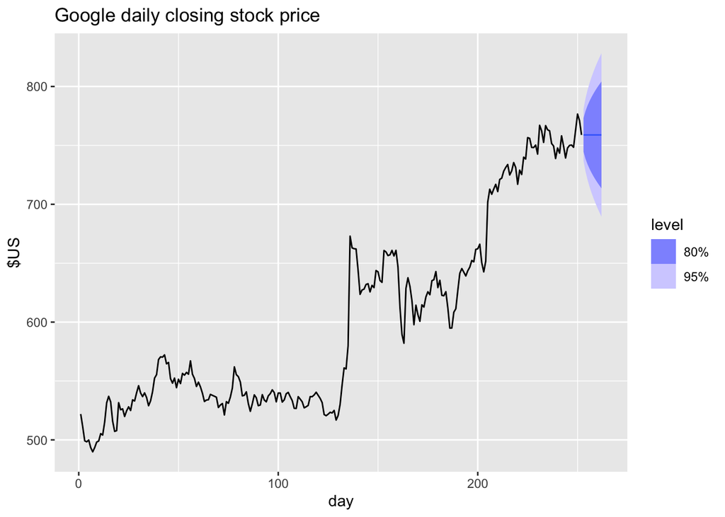

```r
google_2015 |>
  model(NAIVE(Close)) |>
  forecast(h = 10) |>
  autoplot(google_2015) +
  labs(title="Google daily closing stock price", y="$US" )
```

### Prediction intervals from bootstrapped residuals

정규 분포 가정이 적절하지 않을 경우, **부트스트랩(bootstrapping)**을 사용하여 예측 구간을 생성할 수 있음.  
부트스트랩 방법은 **잔차가 비상관성(uncorrelated)이며 분산이 일정함**을 가정함.  
여기서는 **나이브(naïve) 예측 방법**을 이용하여 과정을 설명함.

#### 1단계 예측 오차 정의

$$e_t = y_t - \hat{y}_{t|t-1}$$

나이브 예측에서는,

$$\hat{y}_{t|t-1} = y_{t-1}$$

따라서,

$$y_t = y_{t-1} + e_t$$

즉, 미래 예측은 과거 값과 오차(잔차) 샘플링을 통해 생성됨.

#### 부트스트랩 샘플링을 통한 예측

미래 $t > T$ 시점에서는, 잔차 $e_t$를 과거 잔차에서 **랜덤 샘플링**하여 예측을 수행.

$$y^*_{T+1} = y_T + e^*_{T+1}$$

- $e^*_{T+1}$ : 과거 잔차에서 랜덤 샘플링된 값
- $y^*_{T+1}$ : 미래에 발생할 수 있는 **가능한 값** (실제 값이 아님)

이를 반복하여,

$$y^*_{T+2} = y^*_{T+1} + e^*_{T+2}$$

- 이 과정을 반복하면 **미래 시계열의 여러 가능한 시뮬레이션을 생성할 수 있음**
- 이를 통해 예측 불확실성을 반영한 **부트스트랩 기반 예측 구간**을 생성 가능

```r
fit <- google_2015 |>
  model(NAIVE(Close))
sim <- fit |> generate(h = 30, times = 5, bootstrap = TRUE)
sim
```

```
## # A tsibble: 150 x 5 [1]
## # Key:       Symbol, .model, .rep [5]
##    Symbol .model         day .rep   .sim
##    <chr>  <chr>        <dbl> <chr> <dbl>
##  1 GOOG   NAIVE(Close)   253 1      762.
##  2 GOOG   NAIVE(Close)   254 1      757.
##  3 GOOG   NAIVE(Close)   255 1      747.
##  4 GOOG   NAIVE(Close)   256 1      752.
##  5 GOOG   NAIVE(Close)   257 1      771.
##  6 GOOG   NAIVE(Close)   258 1      779.
##  7 GOOG   NAIVE(Close)   259 1      783.
##  8 GOOG   NAIVE(Close)   260 1      768.
##  9 GOOG   NAIVE(Close)   261 1      750.
## 10 GOOG   NAIVE(Close)   262 1      743.
## # ℹ 140 more rows
```

여기서는 향후 30 거래일 동안의 5가지 가능한 샘플 경로를 생성하였다. .rep 변수는 tsibble 데이터에서 새로운 키 역할을 한다. 아래 그래프는 과거 데이터와 함께 5개의 샘플 경로를 시각화한 것을 보여준다.

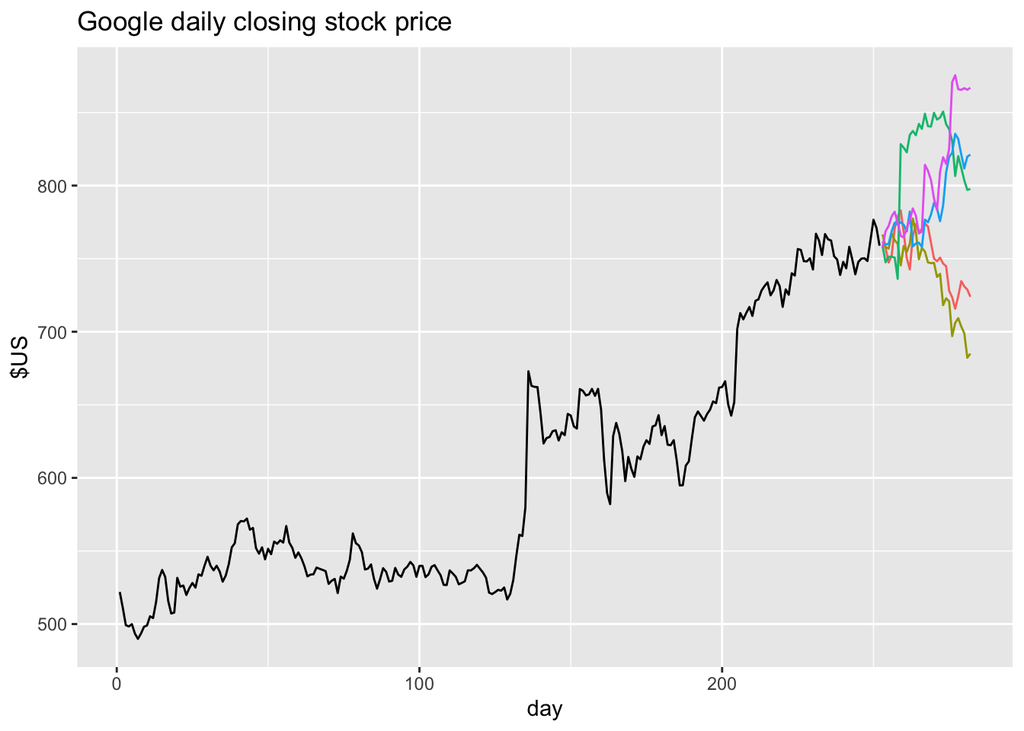

```r
google_2015 |>
  ggplot(aes(x = day)) +
  geom_line(aes(y = Close)) +
  geom_line(aes(y = .sim, colour = as.factor(.rep)),
    data = sim) +
  labs(title="Google daily closing stock price", y="$US" ) +
  guides(colour = "none")
```

그런 다음, 각 예측 시점에 대해 미래 샘플 경로의 퍼센타일(percentiles)을 계산하여 예측 구간을 생성할 수 있다. 이 결과를 **부트스트랩 예측 구간(bootstrapped prediction interval)**이라고 한다.

“부트스트랩(bootstrap)”이라는 용어는 스스로를 끌어올린다는 의미에서 유래되었으며, 이 과정은 과거 데이터만을 이용하여 미래의 불확실성을 측정할 수 있도록 해준다.

이 모든 과정은 forecast() 함수에 내장되어 있으므로, generate() 함수를 직접 호출할 필요는 없다.

```r
fc <- fit |> forecast(h = 30, bootstrap = TRUE)
fc
```

```
## # A fable: 30 x 5 [1]
## # Key:     Symbol, .model [1]
##    Symbol .model         day        Close .mean
##    <chr>  <chr>        <dbl>       <dist> <dbl>
##  1 GOOG   NAIVE(Close)   253 sample[5000]  759.
##  2 GOOG   NAIVE(Close)   254 sample[5000]  759.
##  3 GOOG   NAIVE(Close)   255 sample[5000]  759.
##  4 GOOG   NAIVE(Close)   256 sample[5000]  759.
##  5 GOOG   NAIVE(Close)   257 sample[5000]  759.
##  6 GOOG   NAIVE(Close)   258 sample[5000]  759.
##  7 GOOG   NAIVE(Close)   259 sample[5000]  759.
##  8 GOOG   NAIVE(Close)   260 sample[5000]  760.
##  9 GOOG   NAIVE(Close)   261 sample[5000]  760.
## 10 GOOG   NAIVE(Close)   262 sample[5000]  760.
## # ℹ 20 more rows
```

예측 분포는 이제 5000개의 샘플 경로를 이용한 시뮬레이션으로 표현된다. 정규성(normality) 가정을 하지 않기 때문에, 예측 구간이 대칭적이지 않을 수도 있다.

.mean 열은 부트스트랩 샘플들의 평균값을 나타내므로, 부트스트랩을 사용하지 않은 경우의 결과와 약간 다를 수 있다.

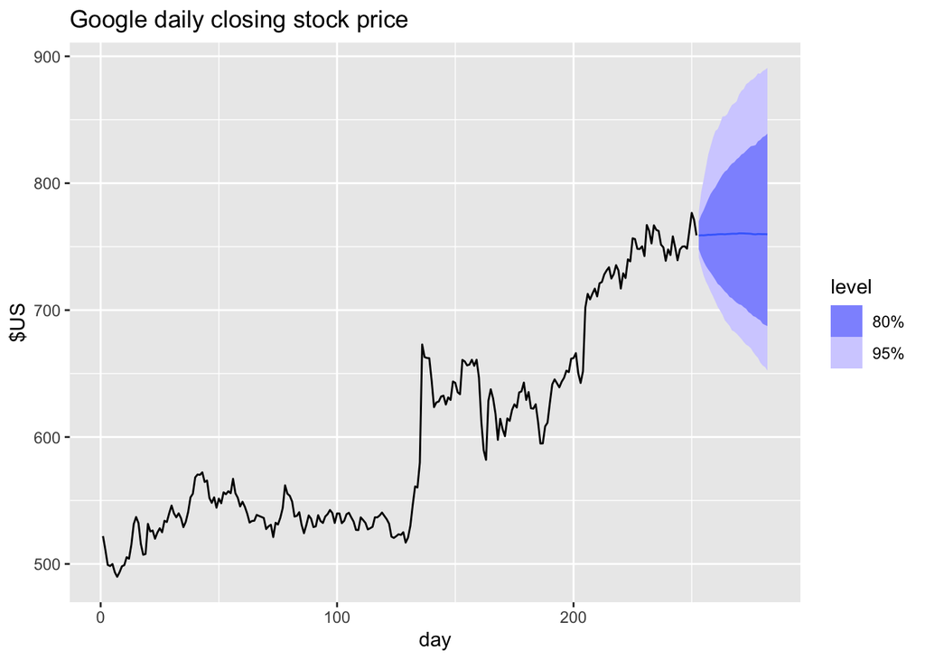

```r
autoplot(fc, google_2015) +
  labs(title="Google daily closing stock price", y="$US" )
```

샘플 개수는 forecast() 함수의 times 인수를 사용하여 조정할 수 있다. 예를 들어, 1000개의 부트스트랩 샘플을 기반으로 예측 구간을 생성하려면 다음과 같이 설정할 수 있다.

```r
google_2015 |>
  model(NAIVE(Close)) |>
  forecast(h = 10, bootstrap = TRUE, times = 1000) |>
  hilo()
```

```
## # A tsibble: 10 x 7 [1]
## # Key:       Symbol, .model [1]
##    Symbol .model         day        Close .mean                  `80%`
##    <chr>  <chr>        <dbl>       <dist> <dbl>                 <hilo>
##  1 GOOG   NAIVE(Close)   253 sample[1000]  759. [748.0260, 769.8420]80
##  2 GOOG   NAIVE(Close)   254 sample[1000]  759. [743.5180, 774.8980]80
##  3 GOOG   NAIVE(Close)   255 sample[1000]  759. [739.1352, 778.0900]80
##  4 GOOG   NAIVE(Close)   256 sample[1000]  759. [735.1624, 780.7056]80
##  5 GOOG   NAIVE(Close)   257 sample[1000]  759. [731.6044, 784.3935]80
##  6 GOOG   NAIVE(Close)   258 sample[1000]  759. [729.8897, 788.3181]80
##  7 GOOG   NAIVE(Close)   259 sample[1000]  759. [727.0179, 791.0155]80
##  8 GOOG   NAIVE(Close)   260 sample[1000]  759. [724.1899, 793.9754]80
##  9 GOOG   NAIVE(Close)   261 sample[1000]  759. [722.1527, 797.9948]80
## 10 GOOG   NAIVE(Close)   262 sample[1000]  760. [719.9391, 803.2611]80
## # ℹ 1 more variable: `95%` <hilo>
```

이 경우, 정규 분포를 기반으로 한 예측 구간과 유사하지만 완전히 동일하지는 않다.

[Book 5.5](https://otexts.com/fpp3/prediction-intervals.html)

## 5.6 Forecasting using transformations

예측 모델에서 변환이 사용된 경우, 먼저 **변환된 데이터의 예측값**을 생성한 후,  
이를 **역변환(Back-Transformation)**하여 원래 스케일로 변환해야 함.

Box-Cox 변환(식 3.1)을 사용한 경우, 역변환은 다음과 같음.

$$y_t =
\begin{cases}
\exp(w_t), & \text{if } \lambda = 0 \\
\text{sign}(\lambda w_t + 1) |\lambda w_t + 1|^{1/\lambda}, &
\text{otherwise}
\end{cases}$$

**fable 패키지**는 모델 정의에서 변환이 사용된 경우, **자동으로 역변환을 수행**함.  
이때, 역변환된 예측 분포는 **“변환된 정규 분포(transformed Normal distribution)”**가 됨.

### Prediction intervals with transformations

- 변환이 적용된 경우, **예측 구간도 변환된 스케일에서 계산 후 역변환 수행**
- 이 과정은 **예측 구간의 확률적 신뢰도를 유지하지만, 대칭성을 잃을 수 있음**
- `fable` 패키지는 모델 공식에서 변환이 적용된 경우, **자동으로 예측 구간을 역변환함**

변환은 **점 예측(point forecast)에 미치는 영향은 작지만, 예측 구간에는 큰 영향을 줄 수 있음**.

### Bias adjustments

Box-Cox 변환을 사용할 경우, **역변환된 점 예측이 예측 분포의 평균(mean)이 아닌 중앙값(median)이 될 수 있음**.  
(변환된 공간에서 분포가 대칭이면, 역변환된 값은 보통 중앙값이 됨)

- 중앙값은 개별 예측에 적절할 수 있으나, **평균이 더 유용한 경우가 많음**  
  (예: 지역별 판매량을 더해 전국 단위 예측을 생성할 때, 중앙값은 더할 수 없음)

Box-Cox 변환을 사용할 경우, **역변환된 평균(mean)의 근사 공식**은 다음과 같음.

$$\hat{y}_{T+h|T} =
\begin{cases}
\exp(\hat{w}_{T+h|T}) \left[1 + \frac{\sigma_h^2}{2} \right], &
\text{if } \lambda = 0 \\
(\lambda \hat{w}_{T+h|T} + 1)^{1/\lambda} \left[1 + \frac{\sigma_h^2
(1-\lambda)^2}{(\lambda \hat{w}_{T+h|T} + 1)^2} \right], &
\text{otherwise}
\end{cases}$$

- $\hat{w}_{T+h|T}$ : **$h$-단계 예측 평균(변환된 공간에서의 값)**
- $\sigma_h^2$ : **$h$-단계 예측 분산(변환된 공간에서의 값)**
- 예측 분산이 클수록, **평균과 중앙값의 차이(편향, bias)**가 커짐

이 차이를 **“편향(bias)”**이라 하며,  
중앙값이 아닌 평균을 사용할 경우 **“편향 조정된 예측(bias-adjusted forecast)”**이라고 함.

## 예제: 드리프트(Drift) 방법과 로그 변환(Log Transformation)

예를 들어, **로그 변환( $\lambda = 0$ )을 적용하여 계란 가격을 예측**한다고 가정.

- 로그 변환을 적용하면, **예측값과 예측 구간이 항상 양수(positive)로 유지됨**
- `fable` 패키지를 이용하면, 자동으로 **편향 조정된 예측값**을 생성 가능

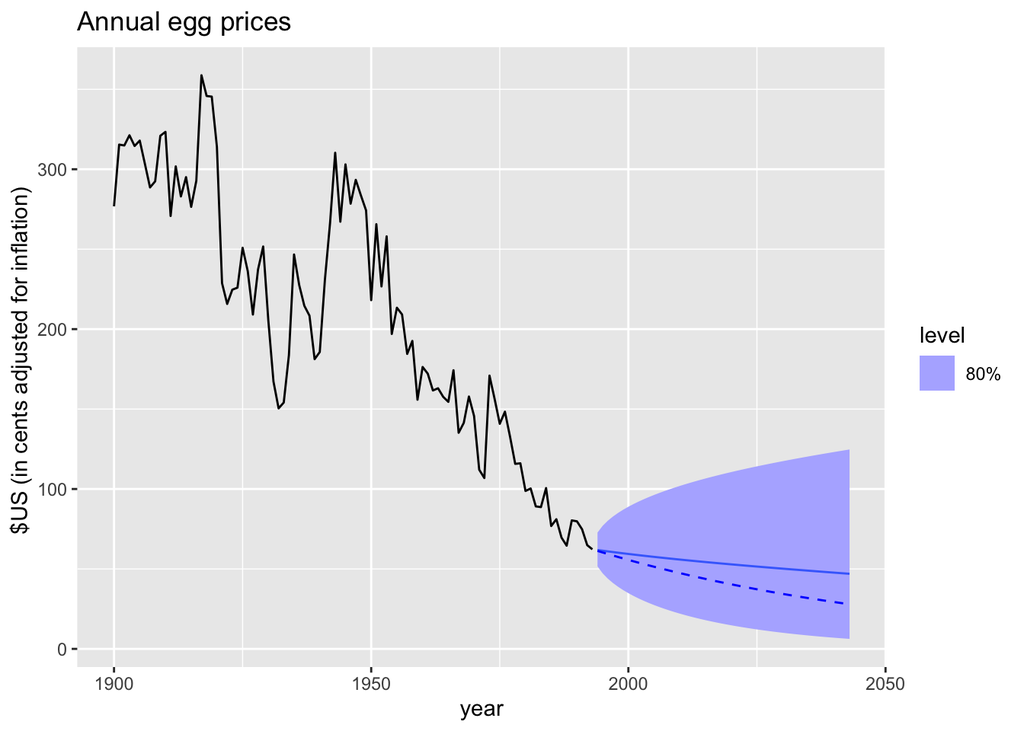

```r
fc <- prices |>
  filter(!is.na(eggs)) |>
  model(RW(log(eggs) ~ drift())) |>
  forecast(h = 50) |>
  mutate(.median = median(eggs))
fc |>
  autoplot(prices |> filter(!is.na(eggs)), level = 80) +
  geom_line(aes(y = .median), data = fc, linetype = 2, col = "blue") +
  labs(title = "Annual egg prices",
       y = "$US (in cents adjusted for inflation) ")
```

그림 5.17에서 **점선(dashed line)**은 **예측 중앙값(median)**을 나타내고, **실선(solid line)**은 **예측 평균(mean)**을 나타낸다. 비대칭(skewed) 예측 분포로 인해 예측 평균이 중앙값보다 더 높아지는 현상을 확인할 수 있으며, 이는 편향 조정(bias adjustment)에 의해 추가된 항의 결과이다.

fable 패키지에서는 자동으로 편향 조정된 예측 평균을 계산한다. 편향 조정 이전의 예측 중앙값(기본 점 예측 값)은 median() 함수를 사용하여 분포 열에서 추출 가능하다.